# What Makes A Video Game Successful?

*** - A dig into the world of video nerds - ***

**Peter Duronelly, MSc of BA, Fall, 2017**

This project is a part of a larger project by Anna Hancsák of CEU **Center for Network Science** which is trying to find those network properties which make teams and their products successful.

The subject of this particular research is the world of video games. This product was picked because of the handy dataset of *www.mobygames.com* where game enthusiast (mostly nerds) collect and contribute information on video games in a structured format.

My part of the project is far from finished. The following short presentation describes what I used from what I had learned in Scientific Python. As you will see, I did not need to use every class, but I have (sometimes extensively) used the following tools and features:

- lists, dictionaries (a lot!), pandas
- web scraping
- error handling / 'trycatch'
- network buidling
- matplotlib

Note: I am not a game enthusiast in any sense, but the project itself is interesting.

### *The datasource*

All data is coming from *www.mobygames.com*.

[figure not shown]

Every game has a page where game description, list of major features, developer info, and review & rating contributions are found.

[figure not shown]

Some the data had already been collected before I started my project in the following structure:

1. file: developer_id, game_id, platform_id, title_original
2. file: developer_id, developer_name
3. file: game_id, game_name
4. file: game_id platform_id, release_date, moby_rank, moby_score, publisher, developer, genre, perspective, visual, gameplay, interface, narrative
5. file: a list of the games's url snippets (eg: "/game/windows/007-blood-stone/credits")

What we missed:

- scores given by 'professional' critics (aka nerds): average score and the number of reviews by games and platforms
- 'novelty score': how much a game is different from those games which have been released within a certain period before its release date

The earliest game in the dataset comes from 1966 (!), the latest is from 2017.

### *Scraping for credit scores (reviews)*

Each game has reviews with text and a numeric score. I needed to scrape the pages for these score. As the pages are well structured, the scores (point grades) are straightforward to get. The only problem is that sometimes:

- a game is not scored and reviewed at all,
- there is a review, but the score is missing (the box is empty, containing a non-numeric character.

**Reviews for a James Bond-game for Windows**

[figure not shown]

The next code snippet gets the url fragments, and lists them into a dictionary of {game names, full urls}.

- **Input**: a text file of url fragments</h1>
- **Output**: a dictionary, where keys: game names; values: full urls

```python
gamesdict = {}
g = open("game_urls_all.txt")
for line in g:
    h = len(line)
    url = "http://www.mobygames.com" + line[0:h - 8] + "mobyrank"
    game = line.split("/")
    game = game[2] + "-" + game[3]
    gamesdict[game] = url
g.close()
```

Scraping for credit scores.

- **Input**: dictionary of game/url pairs
- **Output**: a csv of game names, average credit scores, number of ratings

```python
critic_scores = {}
for game in gamesdict.keys():
    u = gamesdict[game]
    response = requests.get(u).text
    text = response.split("scoreBoxMed score")
    score = 0
    numberofratings = 0
    if len(text) == 2:
        ratinginfo = (0,0)
    else:
        for i in range(2, len(text)):
            t = text[i].split(">")
            try:
                s = int(t[1][0:2])
            except ValueError:
                s = 0
            else:
                score = score + s
                numberofratings = numberofratings + 1
        if numberofratings == 0:
            ratinginfo = (0,0)
        else:
            ratinginfo = (int(round(score / numberofratings,0)), numberofratings)
    critic_scores[game] = ratinginfo
(pd.DataFrame.from_dict(data=critic_scores, orient='index').to_csv('critic_scores.csv', header=["game","score"]))
```

- Note 1: the games came from two lists: one for single platform games, one from multiplatform games. The two lists overlapped, so additional data cleaning was necessary.
- Note 2: the scraping took place in two chunks: one for the single platform and one for the multiplatform games. They ran for 4 and 7 hours, respectively :)

```python
import os, io, requests
import pandas as pd
import numpy as np
import csv
import json
import matplotlib
import matplotlib.pyplot as plt
import string
%matplotlib inline
from scipy import spatial
import networkx as nx
from itertools import combinations
```

```python
df_critic_scores = pd.read_csv('combined_critic_scores.csv',header=0,sep=',')
```

```python
df_critic_scores.rename(columns={'Unnamed: 0': 'game', 'score': 'score', 'numberofratings': 'numberofratings'}, inplace=True)
```

```python
df_critic_scores.head()
```

|  | game | score | numberofratings |
| --- | --- | --- | --- |
| 0 | computer-space | 0 | 0 |
| 1 | galaxy-game | 0 | 0 |
| 2 | baseball__ | 0 | 0 |
| 3 | cat-and-mouse-football-haunted-house | 0 | 0 |
| 4 | computer-space-ball | 0 | 0 |

As it turns out, approximately 50 percent of the games are not rated. the dataframe is then cleaned of the games which have no scores.

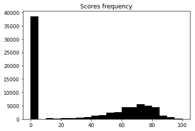

```python
fig = plt.figure()
bins = [i for i in range(0,105,5)]
plt.hist(df_critic_scores["score"], bins, color = "k")
plt.title("Scores frequency")
plt.show()
```

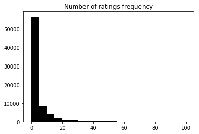

```python
fig = plt.figure()
bins = [i for i in range(0,105,5)]
plt.hist(df_critic_scores["numberofratings"], bins, color = "k")
plt.title("Number of ratings frequency")
plt.show()
```

```python
df_non_zero_scores = df_critic_scores[df_critic_scores["score"]>0]
```

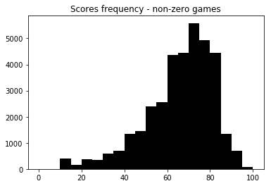

```python
fig = plt.figure()
bins = [i for i in range(0,105,5)]
plt.hist(df_non_zero_scores["score"], bins, color = "k")
plt.title("Scores frequency - non-zero games")
plt.show()
```

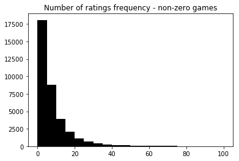

```python
fig = plt.figure()
bins = [i for i in range(0,105,5)]
plt.hist(df_non_zero_scores["numberofratings"], bins, color="k")
plt.title("Number of ratings frequency - non-zero games")
plt.show()
```

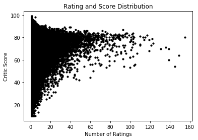

```python
fig = plt.figure()
plt.scatter(df_non_zero_scores["numberofratings"], df_non_zero_scores["score"], color = "k", s = 10)
plt.xlabel("Number of Ratings")
plt.ylabel("Critic Score")
plt.title("Rating and Score Distribution")
plt.show()
```

### *Determining the level of novelty for a game*

Each game has something from the list of features. These features can be mutually exclusive (like perspective) or optional (eg gameplay).

[figure not shown]

I made the union of these features to be able to define a feature vector for all games.

- **Input**: a csv file with the game and platform ids, release dates, and the features included in the game.
- **Output**: a list of all features (strings) found in the dataset. The vector has exactly 100 elements.

Every game is a point in this 100-dimensional space, where all dimensions can take a value of either zero or one.

```python
features_list = []
with open('title.csv') as csvfile:
    readCSV = csv.reader(csvfile, delimiter=',')
    count = 0
    for row in readCSV:
        if count > 0:
            for i in range(7,13):
                text = row[i].split(", ")
                for j in range(0, len(text)):
                    f = text[j]
                    if f != "null" and f not in features_list:
                        features_list.append(f)
        count = count + 1
```

Next I defined the average vector values for each year: that is the 'average' feature of the games released in that particular year.

- **Input**: a csv file with the game and platform ids, release dates, and the features included in the game.
- **Output**: a dictionary, where keys are years, values are 100-element vectors with values of 0 and 1.

```python
annual_avg_feature_vector = {}
for i in range(1966,2018):
    annual_avg_feature_vector[i] = [x * 0 for x in range(0,100)]
games_per_year = {}
for i in range(1966,2018):
    games_per_year[i] = 0

with open('title.csv') as csvfile:
    readCSV = csv.reader(csvfile, delimiter=',')
    rowcount = 0
    for row in readCSV:
        if rowcount > 0:
            for y in range(1966, 2018):
                year = row[2].split("-")[0]
                year = int(year)
                game_features = []
                if year == y:
                    for i in range(7,13):
                        text = row[i].split(",")
                        for m in range(0, len(text)):
                            f = text[m]
                            if f != "null" and f not in game_features:
                                game_features.append(f)
                    j = 0
                    for k in features_list:
                        if k in game_features:
                            annual_avg_feature_vector[y][j] = annual_avg_feature_vector[y][j] +1
                        j = j + 1
                    games_per_year[y] = games_per_year[y] + 1
        rowcount = rowcount + 1
for y in range(1966, 2018):
    if games_per_year[y] > 0:
        annual_avg_feature_vector[y] = [element / games_per_year[y] for element in annual_avg_feature_vector[y]]
```

And now comes the novelty score for a game: a game's degree of novelty is the cosine of the angle it closes with the average game in this multidimensional space. In theory, **cosine similarity** "ranges from −1 meaning exactly opposite, to 1 meaning exactly the same, with 0 indicating orthogonality (decorrelation), and in-between values indicating intermediate similarity or dissimilarity" (wikipedia). In our case, values are expected to be between (0,1).

**Cosine similarity**

[figure not shown]

- **Input**: a csv file with the game and platform ids, release dates, and the features included in the game.
- **Output**: a dataframe of panda dataframe of game id, platform id, cosine similarity

```python
cosines = pd.DataFrame(columns = ["game_id", "platform_id", "cosine_similarity"])


with open('title.csv') as csvfile:
    readCSV = csv.reader(csvfile, delimiter=',')
    count = 0
    rows_in_dataframe = 0 # the actual number of rows we are having in the dataframe; we start with and empty frame
    for row in readCSV:
        if count > 0:
            clist = [] # temp list for game_id, platform_id, similarity
            game_id = row[0]
            platform_id = row[1]
            year = row[2].split("-")[0]
            year = int(year)
            game_features = [] # temp list for the game's features; as long as the number of features
            vector = [] # feature vector of 1s and 0s of the game; length: always 100
            for i in range(7,13):
                text = row[i].split(", ")
                for j in range(0, len(text)):
                    f = text[j]
                    if f != "null" and f not in game_features:
                        game_features.append(f)
            for k in features_list:
                if k in game_features:
                    vector.append(1)
                else:
                    vector.append(0)
            clist.append(game_id)
            clist.append(platform_id)
            try:
                sim = 1 - spatial.distance.cosine(annual_avg_feature_vector[year], vector) # there are 17 zero vectors
            except RuntimeWarning:
                clist.append(1)
            else:
                clist.append(sim)
            cosines.loc[rows_in_dataframe] = clist
            #print(clist, " ", rows_in_dataframe)
            rows_in_dataframe = rows_in_dataframe + 1
        count = count + 1
```

```python
df_cosine_similarities = pd.read_csv('cosine_similarities.csv',header=0,sep=',')
```

```python
df_cosine_similarities.head()
```

|  | game_id | platform_id | cosine_similarity |
| --- | --- | --- | --- |
| 0 | 1 | 1 | 0.241811 |
| 1 | 2 | 2 | 0.526928 |
| 2 | 3 | 3 | 0.564766 |
| 3 | 4 | 4 | 0.742951 |
| 4 | 5 | 3 | 0.137658 |

```python
df_cosine_similarities = df_cosine_similarities.dropna()
```

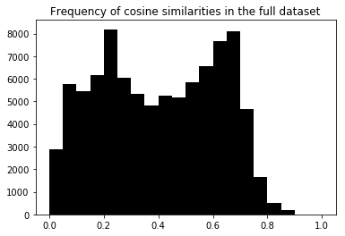

```python
fig = plt.figure()
bins = [i / 20 for i in range(0,21,1)]
plt.hist(df_cosine_similarities["cosine_similarity"], bins, color="k")
plt.title("Frequency of cosine similarities in the full dataset")
plt.show()
```

### *A look into James Bond games*

Next I am looking into James Bod games. How successful are they? What similarities do they have? How the developer teams are related?

Getting the dataframe for JB games:

- **Input**: a csv file with the game and platform ids, release dates, and the features included in the game.
- **Output**: a pd dataframe limited to James Bond games with cosine similarities.

```python
df_JB_games=pd.read_csv('title.csv',header=0,sep=',')
```

Which are the James Bond games? Their theme ('narrative') is "spy / espionage", and they have '007' in the title.

```python
df_JB_games.head()
```

|  | game_id | platform_id | release_date | moby_rank | moby_score | publisher | developer | genre | perspective | visual | gameplay | interface | narrative |
| --- | --- | --- | --- | --- | --- | --- | --- | --- | --- | --- | --- | --- | --- |
| 0 | 1 | 1 | 1986-09-25 | null | null | Robtek Ltd. | null | Strategy/Tactics | Top-down | Fixed / Flip-screen | Board Game | Text Parser | null |
| 1 | 2 | 2 | 2009-12-23 | null | null | Square Enix, Inc. | Gulti Co., Ltd. | Action | Top-down | null | Shooter | null | null |
| 2 | 3 | 3 | 2016-11-16 | null | null | Zero Day Games | Zero Day Games | Action | 1st-person | null | Shooter | Direct Control | null |
| 3 | 4 | 4 | 1981-09-25 | null | null | SEGA Enterprises Ltd. | SEGA Enterprises Ltd. | Action | Top-down | Fixed / Flip-screen | Arcade, Stealth | Direct Control | null |
| 4 | 5 | 3 | 2003-09-24 | null | null | null | null | Adventure | Side view | 2D scrolling | Graphic Adventure | Point and Select | Comedy, Detective / Mystery |

```python
df_JB_games = df_JB_games[df_JB_games["narrative"] == "Spy / Espionage"]
```

Adding the title of the games to the dataframe, and searching for '007'.

```python
df_game_names = pd.read_csv('game.csv',header=0,sep=',')
```

```python
df_JB_games = pd.merge(df_JB_games, df_game_names, how='left', left_on='game_id', right_on='game_id')
```

```python
def jamesbond (input_var):
    s = str(input_var)
    if s[0:3] == "007":
        return 1
    else:
        return 0
df_JB_games["James_Bond_games"] = df_JB_games["game_name"].apply(jamesbond)
```

```python
df_JB_games = df_JB_games[df_JB_games["James_Bond_games"] == 1]
```

```python
df_JB_games.head()
```

|  | game_id | platform_id | release_date | moby_rank | moby_score | publisher | developer | genre | perspective | visual | gameplay | interface | narrative | game_name | James_Bond_games |
| --- | --- | --- | --- | --- | --- | --- | --- | --- | --- | --- | --- | --- | --- | --- | --- |
| 5 | 6 | 5 | 2001-11-15 | null | null | Electronic Arts, Inc. | Electronic Arts Canada, Electronic Arts Redwoo... | Action | 1st-person | null | null | null | Spy / Espionage | 007: Agent Under Fire | 1 |
| 6 | 7 | 6 | 1982-09-25 | null | null | American Software Design and Distribution Company | null | Adventure | Text-based / Spreadsheet | null | Interactive Fiction / Text Adventure | Text Parser | Spy / Espionage | 007: Aqua Base | 1 |
| 7 | 8 | 7 | 2010-11-02 | null | null | Activision Publishing, Inc. | Bizarre Creations, Ltd. | Action, Racing / Driving | Behind view | null | Shooter, Stealth | null | Spy / Espionage | 007: Blood Stone | 1 |
| 10 | 11 | 5 | 2005-10-26 | null | null | Electronic Arts, Inc. | Electronic Arts Redwood Shores Studio | Action, Racing / Driving | Behind view | null | null | null | Spy / Espionage | 007: From Russia with Love | 1 |
| 13 | 14 | 7 | 2012-10-16 | null | null | Activision Publishing, Inc. | Eurocom Developments Ltd | Action | 1st-person | null | Shooter, Stealth | null | Spy / Espionage | 007: Legends | 1 |

Adding cosine similarities.

```python
df_JB_games = pd.merge(df_JB_games, df_cosine_similarities, how='left', left_on=['game_id', 'platform_id'], right_on=['game_id', 'platform_id'])
```

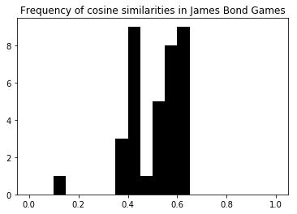

```python
fig = plt.figure()
bins = [i / 20 for i in range(0,21,1)]
plt.hist(df_JB_games["cosine_similarity"], bins, color="k")
plt.title("Frequency of cosine similarities in James Bond Games")
plt.show()
```

```python
df_JB_games
```

|  | game_id | platform_id | release_date | moby_rank | moby_score | publisher | developer | genre | perspective | visual | gameplay | interface | narrative | game_name | James_Bond_games | cosine_similarity |
| --- | --- | --- | --- | --- | --- | --- | --- | --- | --- | --- | --- | --- | --- | --- | --- | --- |
| 0 | 6 | 5 | 2001-11-15 | null | null | Electronic Arts, Inc. | Electronic Arts Canada, Electronic Arts Redwoo... | Action | 1st-person | null | null | null | Spy / Espionage | 007: Agent Under Fire | 1 | 0.576078 |
| 1 | 7 | 6 | 1982-09-25 | null | null | American Software Design and Distribution Company | null | Adventure | Text-based / Spreadsheet | null | Interactive Fiction / Text Adventure | Text Parser | Spy / Espionage | 007: Aqua Base | 1 | 0.133387 |
| 2 | 8 | 7 | 2010-11-02 | null | null | Activision Publishing, Inc. | Bizarre Creations, Ltd. | Action, Racing / Driving | Behind view | null | Shooter, Stealth | null | Spy / Espionage | 007: Blood Stone | 1 | 0.381212 |
| 3 | 11 | 5 | 2005-10-26 | null | null | Electronic Arts, Inc. | Electronic Arts Redwood Shores Studio | Action, Racing / Driving | Behind view | null | null | null | Spy / Espionage | 007: From Russia with Love | 1 | 0.425347 |
| 4 | 14 | 7 | 2012-10-16 | null | null | Activision Publishing, Inc. | Eurocom Developments Ltd | Action | 1st-person | null | Shooter, Stealth | null | Spy / Espionage | 007: Legends | 1 | 0.512239 |
| 5 | 14 | 7 | 2012-10-16 | null | null | Activision Publishing, Inc. | Eurocom Developments Ltd | Action | 1st-person | null | Shooter, Stealth | null | Spy / Espionage | 007: Legends | 1 | 0.512239 |
| 6 | 15 | 11 | 1989-09-25 | null | null | Domark Ltd. | Quixel | Action, Racing / Driving | Top-down | null | Arcade, Shooter | null | Spy / Espionage | 007: Licence to Kill | 1 | 0.603071 |
| 7 | 15 | 11 | 1989-09-25 | null | null | Domark Ltd. | Quixel | Action, Racing / Driving | Top-down | null | Arcade, Shooter | null | Spy / Espionage | 007: Licence to Kill | 1 | 0.603071 |
| 8 | 16 | 5 | 2002-11-25 | null | null | Electronic Arts, Inc. | Eurocom Developments Ltd, Savage Entertainment... | Action, Racing / Driving | Behind view | null | null | null | Spy / Espionage | 007: Nightfire | 1 | 0.431808 |
| 9 | 16 | 5 | 2002-11-25 | null | null | Electronic Arts, Inc. | Eurocom Developments Ltd, Savage Entertainment... | Action, Racing / Driving | Behind view | null | null | null | Spy / Espionage | 007: Nightfire | 1 | 0.431808 |
| 10 | 16 | 12 | 2002-11-28 | null | null | Electronic Arts, Inc. | Gearbox Software LLC | Action | 1st-person | null | null | null | Spy / Espionage | 007: Nightfire | 1 | 0.588874 |
| 11 | 16 | 9 | 2003-03-28 | null | null | Electronic Arts, Inc. | JV Games, Inc. | Action | 1st-person | null | Shooter | null | Spy / Espionage | 007: Nightfire | 1 | 0.593365 |
| 12 | 18 | 14 | 2000-11-21 | null | 3.3 | Electronic Arts, Inc. | Electronic Arts Canada, Eutechnyx Limited | Action, Racing / Driving | Behind view | null | Shooter | null | Spy / Espionage | 007: Racing | 1 | 0.438520 |
| 13 | 19 | 15 | 2000-10-17 | null | 3.5 | Electronic Arts, Inc. | Eurocom Developments Ltd | Action | 1st-person | null | Shooter | null | Spy / Espionage | 007: The World is Not Enough | 1 | 0.562634 |
| 14 | 19 | 14 | 2000-09-08 | null | 3.2 | Electronic Arts, Inc. | Black Ops Entertainment, LLC | Action | 1st-person | null | Shooter | null | Spy / Espionage | 007: The World is Not Enough | 1 | 0.562634 |
| 15 | 19 | 16 | 2001-09-25 | null | null | Electronic Arts, Inc. | 2n Productions | Action | Top-down | null | Shooter | null | Spy / Espionage | 007: The World is Not Enough | 1 | 0.456146 |
| 16 | 6 | 13 | 2001-11-15 | null | 3.1 | Electronic Arts, Inc. | Electronic Arts Canada, Electronic Arts Redwoo... | Action | 1st-person | null | null | null | Spy / Espionage | 007: Agent Under Fire | 1 | 0.576078 |
| 17 | 6 | 99 | 2002-03-25 | null | null | Electronic Arts, Inc. | Electronic Arts Canada, Electronic Arts Redwoo... | Action | 1st-person | null | null | null | Spy / Espionage | 007: Agent Under Fire | 1 | 0.588874 |
| 18 | 8 | 3 | 2010-11-02 | null | null | Activision Publishing, Inc. | Bizarre Creations, Ltd. | Action, Racing / Driving | Behind view | null | Shooter, Stealth | null | Spy / Espionage | 007: Blood Stone | 1 | 0.381212 |
| 19 | 8 | 2 | 2010-11-02 | null | null | Activision Publishing, Inc. | Bizarre Creations, Ltd. | Action, Racing / Driving | Behind view | null | Shooter, Stealth | null | Spy / Espionage | 007: Blood Stone | 1 | 0.381212 |
| 20 | 11 | 13 | 2005-11-01 | null | null | Electronic Arts, Inc. | Electronic Arts Redwood Shores Studio | Action, Racing / Driving | Behind view | null | null | null | Spy / Espionage | 007: From Russia with Love | 1 | 0.425347 |
| 21 | 11 | 38 | 2006-04-03 | null | 3.4 | Electronic Arts, Inc. | Electronic Arts Redwood Shores Studio | Action, Racing / Driving | Behind view | null | null | null | Spy / Espionage | 007: From Russia with Love | 1 | 0.418053 |
| 22 | 14 | 7 | 2012-10-16 | null | null | Activision Publishing, Inc. | Eurocom Developments Ltd | Action | 1st-person | null | Shooter, Stealth | null | Spy / Espionage | 007: Legends | 1 | 0.512239 |
| 23 | 14 | 7 | 2012-10-16 | null | null | Activision Publishing, Inc. | Eurocom Developments Ltd | Action | 1st-person | null | Shooter, Stealth | null | Spy / Espionage | 007: Legends | 1 | 0.512239 |
| 24 | 14 | 3 | 2012-11-02 | null | null | Activision Publishing, Inc. | Eurocom Developments Ltd | Action | 1st-person | null | Shooter, Stealth | null | Spy / Espionage | 007: Legends | 1 | 0.512239 |
| 25 | 15 | 11 | 1989-09-25 | null | null | Domark Ltd. | Quixel | Action, Racing / Driving | Top-down | null | Arcade, Shooter | null | Spy / Espionage | 007: Licence to Kill | 1 | 0.603071 |
| 26 | 15 | 11 | 1989-09-25 | null | null | Domark Ltd. | Quixel | Action, Racing / Driving | Top-down | null | Arcade, Shooter | null | Spy / Espionage | 007: Licence to Kill | 1 | 0.603071 |
| 27 | 15 | 65 | 1989-09-25 | null | null | Domark Ltd. | Quixel | Action, Racing / Driving | Top-down | null | Arcade, Shooter | null | Spy / Espionage | 007: Licence to Kill | 1 | 0.603071 |
| 28 | 15 | 23 | 1989-09-25 | null | null | Domark Ltd. | Quixel | Action, Racing / Driving | Top-down | null | Arcade, Shooter | null | Spy / Espionage | 007: Licence to Kill | 1 | 0.603071 |
| 29 | 15 | 8 | 1989-09-25 | null | null | Domark Ltd. | Quixel | Action, Racing / Driving | Top-down | null | Arcade, Shooter | null | Spy / Espionage | 007: Licence to Kill | 1 | 0.603071 |
| 30 | 15 | 20 | 1989-09-25 | null | 2.8 | Domark Ltd. | Quixel | Action, Racing / Driving | Top-down | null | Arcade, Shooter | null | Spy / Espionage | 007: Licence to Kill | 1 | 0.603071 |
| 31 | 15 | 17 | 1989-09-25 | null | 3.4 | Domark Ltd. | Quixel | Action, Racing / Driving | Top-down | null | Arcade, Shooter | null | Spy / Espionage | 007: Licence to Kill | 1 | 0.603071 |
| 32 | 16 | 3 | 2002-11-28 | null | 3.0 | Electronic Arts, Inc. | Gearbox Software LLC | Action | 1st-person | null | null | null | Spy / Espionage | 007: Nightfire | 1 | 0.588874 |
| 33 | 16 | 5 | 2002-11-19 | null | null | Electronic Arts, Inc. | Eurocom Developments Ltd, Savage Entertainment... | Action, Racing / Driving | Behind view | null | null | null | Spy / Espionage | 007: Nightfire | 1 | 0.431808 |
| 34 | 16 | 5 | 2002-11-19 | null | null | Electronic Arts, Inc. | Eurocom Developments Ltd, Savage Entertainment... | Action, Racing / Driving | Behind view | null | null | null | Spy / Espionage | 007: Nightfire | 1 | 0.431808 |
| 35 | 16 | 99 | 2002-11-20 | null | null | Electronic Arts, Inc. | Eurocom Developments Ltd, Savage Entertainment... | Action, Racing / Driving | Behind view | null | null | null | Spy / Espionage | 007: Nightfire | 1 | 0.431808 |

Note: the remaining games are only Bond games indeed.

### Building the developer network.

Whoe are buliding James Bond gaems? How are they ralated to each other? Let's build their networks!

```python
nx_JB_developers = nx.Graph()
```

First let's read the file with the developer information: developer_id, game_id, platform_id, title_original (professional title of the developer).

```python
df_JB_developers = pd.read_csv('credit.csv',header=0,sep=',')
```

Now we extract the game_ids of James Bond games.

```python
JB_game_ids = df_JB_games["game_id"].tolist() ## This results in a list of multiple entries.
```

```python
JB_game_ids = set(JB_game_ids) ## Reducing to unique values.
```

```python
JB_game_ids = list(JB_game_ids) ## converting back from set to list.
```

```python
JB_game_ids
```

```
[6, 7, 8, 11, 14, 15, 16, 18, 19]
```

Then we filter the developer dataset for James Bond games using the game_ids from our '*df_JB_games*' dataframe.

```python
def keep_bond_developers(id_number):
    if id_number in JB_game_ids:
        return 1
    else:
        return 0
df_JB_developers["Bond_game"] = df_JB_developers["game_id"].apply(keep_bond_developers)
```

```python
df_JB_developers = df_JB_developers[df_JB_developers["Bond_game"] == 1]
```

```python
df_JB_developers.head()
```

|  | developer_id | game_id | platform_id | title_original | Bond_game |
| --- | --- | --- | --- | --- | --- |
| 70 | 817465.0 | 7 | 6 | By | 1 |
| 269 | 169141.0 | 16 | 9 | Programming | 1 |
| 270 | 169140.0 | 16 | 9 | Level Design | 1 |
| 271 | 169144.0 | 16 | 9 | Level Design | 1 |
| 272 | 56244.0 | 16 | 9 | Graphics | 1 |

Since different developer teams develop games per console, we consider a game+platform tuple to be a standalone video game. While the teams may overlap, they are not the same, and we can build a network of James Bond game developers. For this we also need to platform_ids of all Bond games.

```python
platform_ids = df_JB_games["platform_id"].tolist()
platform_ids = set(platform_ids)
platform_ids = list(platform_ids)
platform_ids
```

```
[65, 2, 99, 3, 5, 6, 7, 38, 9, 8, 11, 12, 13, 14, 15, 16, 17, 20, 23]
```

It looks that we have 3232 people who participated in developing for our Bond games. (This probably includes those people who were responsible for coffee...)

```python
dev_ids = df_JB_developers["developer_id"].tolist()
dev_ids  = set(dev_ids)
dev_ids  = list(dev_ids)
len(dev_ids)
```

```
3232
```

Now the network! I looped over the df_JB_developer dataframe by rows. For every single James Bond game_id + platform_id pair I defined a complete network, which I then added to the '*nx_JB_developers*' graph.

- **Input**: the dataframe for James Bond developers, an array for James Bond game_ids, an array of the platform_ids.
- **Output**: a network graph of James Bond Game developers.

```python
nodes = []

for element in JB_game_ids:
    for i in platform_ids:
        nodes = []
        for row in df_JB_developers.itertuples(index=True, name='Pandas'):
            if getattr(row, "game_id") == element and getattr(row, "platform_id") == i :
                nodes.append(int(getattr(row, "developer_id")))
        if len(nodes) > 1:
            edges = combinations(nodes, 2)
            nx_JB_developers.add_nodes_from(nodes)
            nx_JB_developers.add_edges_from(edges)
```

Here is our network!

```python
print(nx.info(nx_JB_developers))
```

```
Name:
Type: Graph
Number of nodes: 3231
Number of edges: 1098983
Average degree: 680.2742
```

The degree frequency, however, looks kinda weird.

```python
JB_degrees=nx.degree(nx_JB_developers)
JB_degrees=np.array(list(JB_degrees.values()))
```

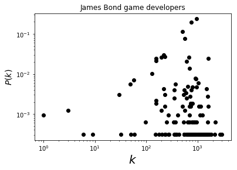

```python
JB_hist, bin_edges= np.histogram(JB_degrees, bins=max(JB_degrees)-min(JB_degrees), density=True)

plt.plot(bin_edges[:-1],JB_hist,'ko')
plt.xlabel(r'$k$', fontsize=20)
plt.ylabel(r'$P\left( k \right)$', fontsize=14)
plt.title("James Bond game developers")
plt.loglog()
plt.show()
```

## Summary

This Scientific Python project summarizes the coding and analytical work done for analyzing the success rate of video games. The underlying project is still in progress, and hopefully can be finished in early 2018. What we need to do yet:

- Connecting critic scores with game_id + platform_id tuples.
- More investigation into novelty, using cosine similarities.
- Building developer networks by games; using network metrics to describe teams.
- Finding the realtionship between success, novelty, team composition and team network metrics.